# Working with data

## Presentation of the Survey Data

The first few rows of the survey dataset look like this:

```
"63","8","19","1977","3","DM","M","40","23"
"64","8","19","1977","7","DM","M","48","25"
"65","8","19","1977","4","DM","F","29","13"
"66","8","19","1977","4","DM","F","46","35"
"67","8","19","1977","7","DM","M","36","11"
```

To load our survey data, we need to locate the `surveys.csv` file. We will use `read.csv()` to load into memory (as a `data.frame`) the content of the CSV file.

```r
download.file("http://files.figshare.com/1919744/surveys.csv", "data/surveys.csv")
download.file("http://files.figshare.com/1919741/species.csv", "data/species.csv")
surveys <- read.csv('data/surveys.csv')
```

This statement doesn’t produce any output because assignment doesn’t display anything. If we want to check that our data has been loaded, we can print the variable’s value: `surveys`

Wow… that was a lot of output. At least it means the data loaded properly. Let’s check the top (the first 6 lines) of this `data.frame` using the function `head()`:

```r
head(surveys)
```

```
##   record_id month day year plot_id species_id sex hindfoot_length weight
## 1         1     7  16 1977       2         NL   M              32     NA
## 2         2     7  16 1977       3         NL   M              33     NA
## 3         3     7  16 1977       2         DM   F              37     NA
## 4         4     7  16 1977       7         DM   M              36     NA
## 5         5     7  16 1977       3         DM   M              35     NA
## 6         6     7  16 1977       1         PF   M              14     NA
```

Let’s now check the **str**ucture of this `data.frame` in more details with the function `str()`:

```r
str(surveys)
```

**Also, show how to get this information from the “Environment” tab in RStudio.**

### Challenge

Based on the output of `str(surveys)`, can you answer the following questions?

- What is the class of the object `surveys`?
- How many rows and how many columns are in this object?
- How many species have been recorded during these surveys?

Other useful functions to get information about `data.frame` objects:

```r
dim(surveys)
nrow(surveys)
ncol(surveys)
colnames(surveys)
names(surveys)
```

As you can see, the columns `species` and `sex` are of a special class called `factor`. Before we learn more about the `data.frame` class, we are going to talk about factors. They are very useful but not necessarily intuitive, and therefore require some attention.

## Factors

Factors are used to represent categorical data. Factors can be ordered or unordered and are an important class for statistical analysis and for plotting.

Factors are stored as integers, and have labels associated with these unique integers. While factors look (and often behave) like character vectors, they are actually integers under the hood, and you need to be careful when treating them like strings.

Once created, factors can only contain a pre-defined set values, known as *levels*. By default, R always sorts *levels* in alphabetical order. For instance, if you have a factor with 2 levels:

```r
sex <- factor(c("male", "female", "female", "male"))
```

R will assign `1` to the level `"female"` and `2` to the level `"male"` (because `f` comes before `m`, even though the first element in this vector is `"male"`). You can check this by using the function `levels()`, and check the number of levels using `nlevels()`:

```r
levels(sex)
nlevels(sex)
```

Sometimes, the order of the factors does not matter, other times you might want to specify the order because it is meaningful (e.g., “low”, “medium”, “high”) or it is required by particular type of analysis. Additionally, specifying the order of the levels allows to compare levels:

```r
food <- factor(c("low", "high", "medium", "high", "low", "medium", "high"))
levels(food)
food <- factor(food, levels=c("low", "medium", "high"))
levels(food)
min(food) ## doesn't work
```

```
## Error in Summary.factor(structure(c(1L, 3L, 2L, 3L, 1L, 2L, 3L), .Label = c("low", : 'min' not meaningful for factors
```

```r
food <- factor(food, levels=c("low", "medium", "high"), ordered=TRUE)
levels(food)
min(food) ## works!
```

In R’s memory, these factors are represented by numbers (1, 2, 3). They are better than using simple integer labels because factors are self describing: `"low"`, `"medium"`, and `"high"`" is more descriptive than `1`, `2`, `3`. Which is low? You wouldn’t be able to tell with just integer data. Factors have this information built in. It is particularly helpful when there are many levels (like the species in our example data set).

### Converting factors

If you need to convert a factor to a character vector, simply use `as.character(x)`.

Converting a factor to a numeric vector is however a little trickier, and you have to go via a character vector. Compare:

```r
f <- factor(c(1, 5, 10, 2))
as.numeric(f)               ## wrong! and there is no warning...
as.numeric(as.character(f)) ## works...
as.numeric(levels(f))[f]    ## The recommended way.
```

### Challenge

The function `table()` tabulates observations and can be used to create bar plots quickly. For instance:

```r
## Question: How can you recreate this plot but by having "control"
## being listed last instead of first?
exprmt <- factor(c("treat1", "treat2", "treat1", "treat3", "treat1", "control",
                   "treat1", "treat2", "treat3"))
table(exprmt)
```

```
## exprmt
## control  treat1  treat2  treat3
##       1       4       2       2
```

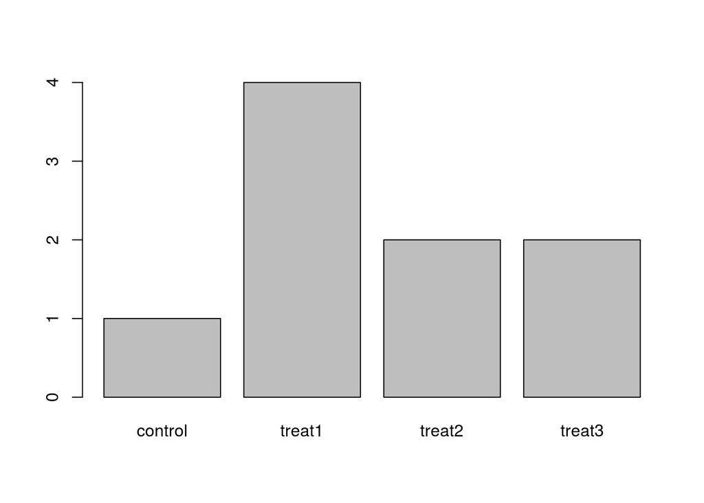

```r
barplot(table(exprmt))
```

## Slicing data

Our survey data frame has rows and columns (it’s a 2-dimensional object), if we want to extract some specific data from it (a slice of it), we need to specify the “coordinates” we want the data to come from. To do this, we use the square bracket notation (just like with vectors), except that we need to add a comma to indicate the rows and columns we want. Row numbers come first, followed by column numbers. Here are some examples:

```r
surveys[1, 1]   # first element in the first column of the data frame
surveys[1, 6]   # first element in the 6th column
surveys[1:3, 7] # first three elements in the 7th column
surveys[3, ]    # the 3rd element for all columns
surveys[, 8]    # the entire 8th column
head_surveys <- surveys[1:6, ] # surveys[1:6, ] is equivalent to head(surveys)
```

### Challenge

1. The function `nrow()` on a `data.frame` returns the number of rows. Use it, in conjuction with `seq()` to create a new `data.frame` called `surveys_by_10` that includes every 10th row of the survey data frame starting at row 10 (10, 20, 30, …)

## Subsetting data

When analyzing data, though, we often want to look at partial statistics, such as the maximum value of a variable per species or the average value per plot.

One way to do this is to select the data we want, and create a new temporary array, using the `subset()` function. For instance, if we just want to look at the animals of the species “DO”:

```r
surveys_DO <- subset(surveys, species == "DO")
```

### Challenge

1. What does the following do (Try to guess without executing it)? `surveys_DO$month[2] <- 8`
2. Use the function `subset` to create a `data.frame` that contains all individuals of the species “DM” that were collected in 2002. How many individuals of the species “DM” were collected in 2002?

## Adding a column to our dataset

Sometimes, you may have to add a new column to your dataset that represents a new variable. You can add columns to a `data.frame` using the function `cbind()` (**c**olumn **bind**). Beware, the additional column must have the same number of elements as there are rows in the `data.frame`.

To use this function, we are going to create a new column that is contain to contain the full date formatted YYYY-MM-DD. The function `paste()` concatenates the strings:

```r
surveys_dates <- paste(surveys$year, surveys$month, surveys$day, sep="-")
length(surveys_dates)
head(surveys_dates)
nrow(surveys)
surveys <- cbind(surveys, full_date = surveys_dates)
```

## Merging two datasets (Join)

In our survey dataset, the species are represented by a 2-letter code (e.g., “AB”), however, we would like to include the species name. The correspondance between the 2 letter code and the names are in the file `species.csv`. In this file, one column includes the genus and another includes the species. First, we are going to import this file in memory:

```r
species <- read.csv("data/species.csv")
```

We are then going to use the function `merge()` to fill in the full species name (Genus, species and taxa) into the `surveys` `data.frame`. To merge two data frames, R looks at the names and performs the merge based on the column that has the same name in both datasets. So let’s get a closer look at our datasets:

```r
colnames(species)
colnames(surveys)
```

In our case the data frames have the correct names and share the `species_id` column that is the 2 letter code used to get the species names.

```r
surveys_species <- merge(surveys, species)
nrow(surveys_species)
nrow(surveys)
```

What is going here?

By default, `merge()` only keeps the rows for which there is an exact match from the first data frame into the second one. Here, because there are some rows that do not include the species name they are removed. To keep them into the resulting data, we need to use the argument `all.x = TRUE`:

```r
surveys_species <- merge(surveys, species, all.x = TRUE)
nrow(surveys_species)
head(surveys_species)
surveys_species <- merge(surveys, species, all.x = TRUE, sort=FALSE)
head(surveys_species)
```

### Challenge

- Use the function `paste()` to add a new column called `genus_species` into the `species` `surveys_species` data frame.
- Use this data set to answer the following:
- How many birds have been captured?
- How many individuals of the genus *Dipodomys* have been captured?

## Removing columns

Just like you can select columns by their positions in the `data.frame` or by their names, you can remove them similarly.

To remove it by column number:

```r
surveys_noDate <- surveys[, -c(3:5)]
colnames(surveys)
```

```
##  [1] "record_id"       "month"           "day"
##  [4] "year"            "plot_id"         "species_id"
##  [7] "sex"             "hindfoot_length" "weight"
## [10] "full_date"
```

```r
colnames(surveys_noDate)
```

```
## [1] "record_id"       "month"           "species_id"      "sex"
## [5] "hindfoot_length" "weight"          "full_date"
```

The easiest way to remove by name is to use the `subset()` function. This time we need to specify explicitly the argument `select` as the default is to subset on rows (as above). The minus sign indicates the names of the columns to remove (note that the column names should not be quoted):

```r
surveys_noDate2 <- subset(surveys, select=-c(month, day, year))
colnames(surveys_noDate2)
```

```
## [1] "record_id"       "plot_id"         "species_id"      "sex"
## [5] "hindfoot_length" "weight"          "full_date"
```